# hw2

Xiang Yang Ng

April 15, 2018

Set your ‘working directory’ to the folder where all the data and respective codes are located.

```r
setwd("/Users/Lenovo/Desktop/Econ 144/Homework/Hw 2")
```

Clear variables and prior sessions

```r
rm(list=ls(all=TRUE))
```

Download all the libraries

```r
library(lattice)
library(foreign)
library(MASS)
library(car)
require(stats)
require(stats4)
library(KernSmooth)
library(fastICA)
library(cluster)
library(leaps)
library(mgcv)
library(rpart)
library(pan)
library(mgcv)
library(DAAG)
library(tis)
```

```r
require(datasets)
require(graphics)
library("forecast")
#require(astsa)
library(xtable)
library(stats)
```

## Problem 1

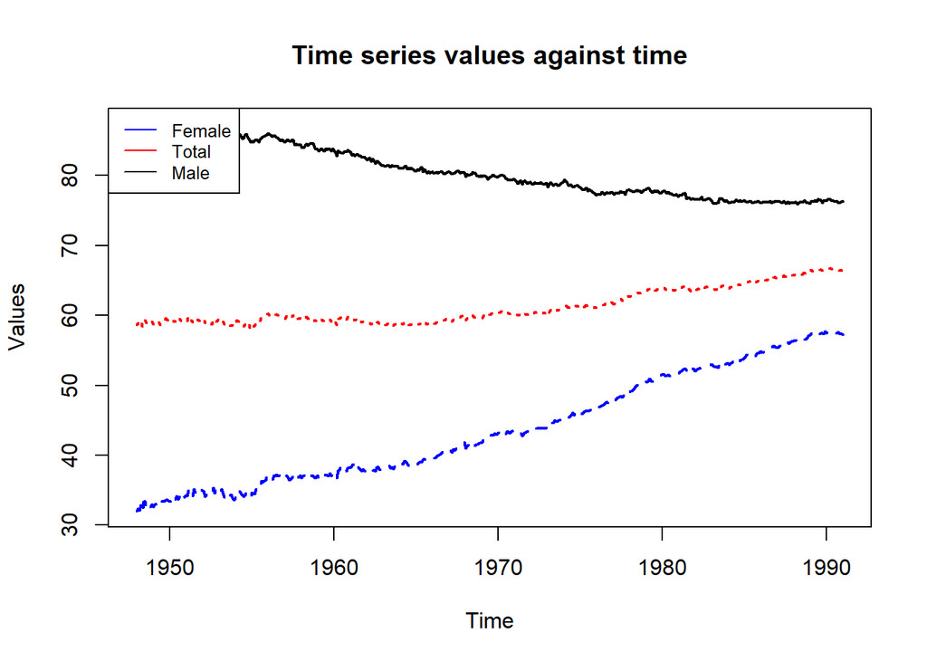

```r
#reading in the data and change the names
z=read.table("labordata.dat")
names(z)= c("male","female","total")
attach(z)

# Convert data to time series format:
male_ts<-ts(male,start=1948,freq=12)
female_ts <- ts(female,start=1948,freq=12)
total_ts <- ts(total,start=1948,freq=12)
t<-seq(1948, 1991,length=length(male_ts))

matplot(t, cbind(male_ts, female_ts, total_ts), xlab = "Time", ylab = "Values",  type="l", lwd=2, col = c("black", "blue", "red"))
title(main = "Time series values against time")
legend("topleft", legend=c("Female", "Total", "Male"),
       col=c("blue", "red", "black"), cex=0.8, lty = 1)
```

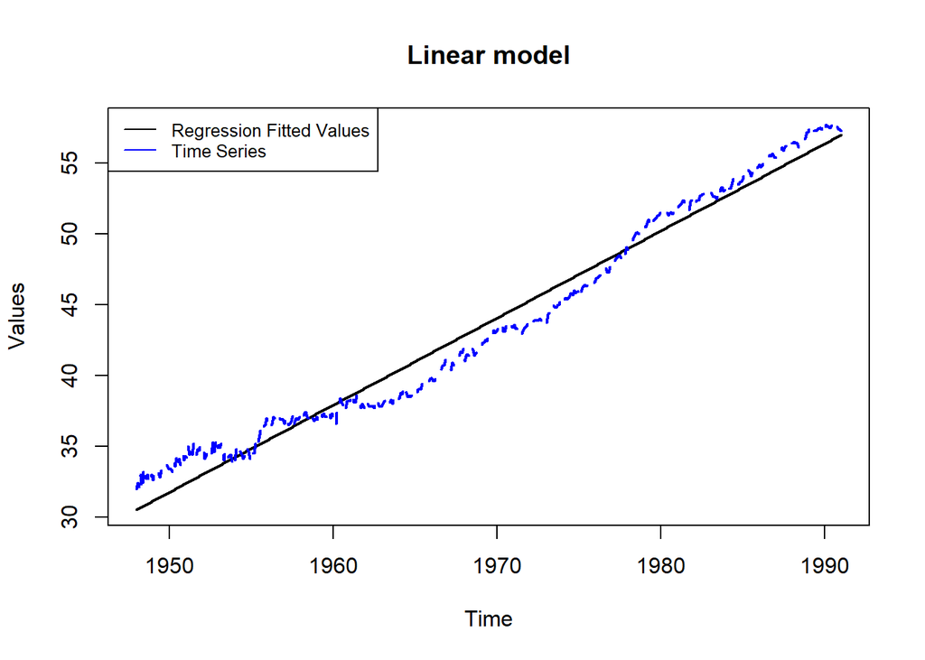

```r
#Linear Model
y1 = lm(female_ts~t)
matplot(t, cbind(y1$fitted.values, female_ts), xlab = "Time", ylab = "Values",  type="l", lwd=2, col = c("black", "blue"))
title(main = "Linear model")
legend("topleft", legend=c("Regression Fitted Values", "Time Series"),
       col=c("black", "blue"), cex=0.8, lty = 1)
```

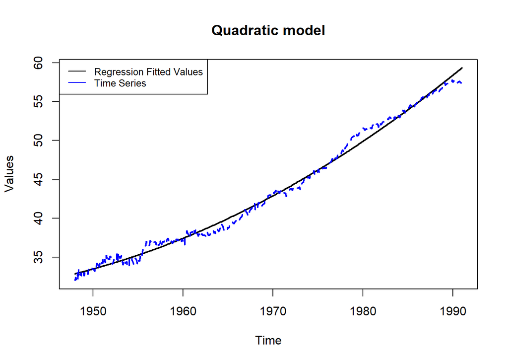

```r
#Quadratic Model
y2 = lm(female_ts~t+I(t^2))
matplot(t, cbind(y2$fitted.values, female_ts), xlab = "Time", ylab = "Values",  type="l", lwd=2, col = c("black", "blue"))
title(main = "Quadratic model")
legend("topleft", legend=c("Regression Fitted Values", "Time Series"),
       col=c("black", "blue"), cex=0.8, lty = 1)
```

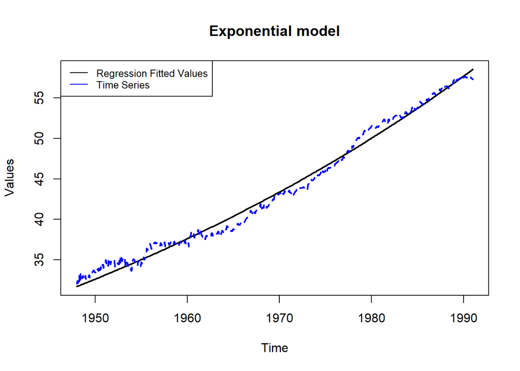

```r
#Exponential Model
ds=data.frame(x=t, y=female_ts)

#using a nonlinear square
y3=nls(y ~ exp(a + b * t),data=ds, start = list(a = 0, b = 0))

matplot(t, cbind(predict(y3, list(x = ds$x)), female_ts), xlab = "Time", ylab = "Values",  type="l", lwd=2, col = c("black", "blue"))
title(main = "Exponential model")
legend("topleft", legend=c("Regression Fitted Values", "Time Series"),
       col=c("black", "blue"), cex=0.8, lty = 1)
```

All 3 models seem to fit the data pretty well based on the plots. However the quadratic and exponential models fit the data better than the linear one.

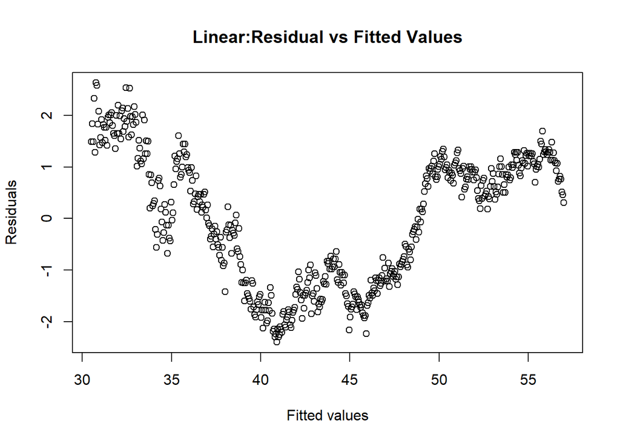

```r
plot(y1$fitted.values, y1$residuals, main = "Linear:Residual vs Fitted Values", ylab = "Residuals", xlab = "Fitted values")
```

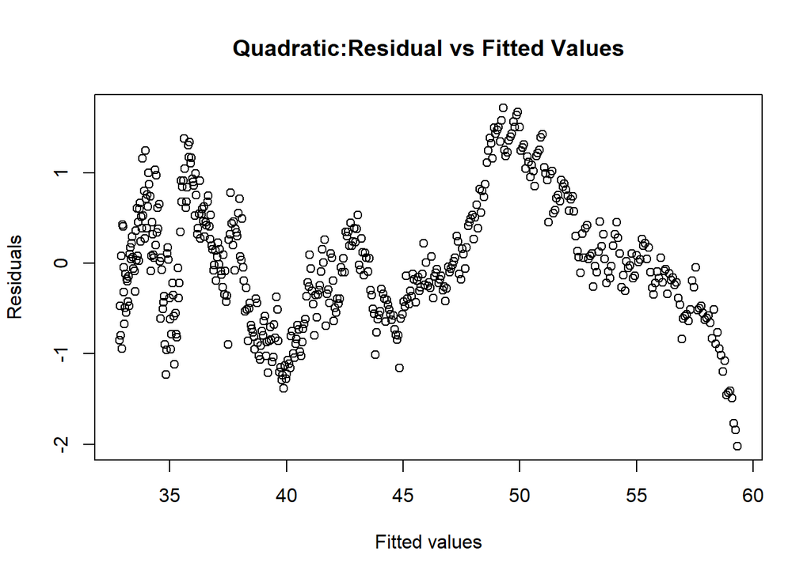

```r
plot(y2$fitted.values, y2$residuals, main = "Quadratic:Residual vs Fitted Values", ylab = "Residuals", xlab = "Fitted values")
```

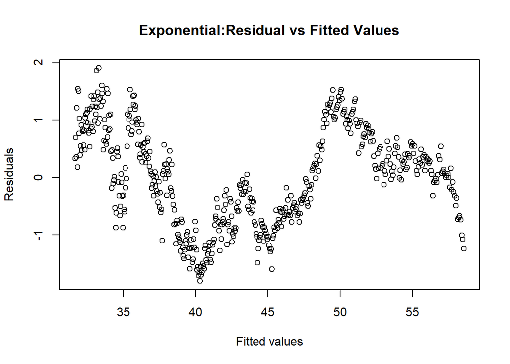

```r
plot(predict(y3, list(x = ds$x)), residuals(y3), main = "Exponential:Residual vs Fitted Values", ylab = "Residuals", xlab = "Fitted values")
```

There seems to be a nonlinear pattern in the plot of residuals vs fitted values for the all model, which suggest that not all the dynamics of the data are accounted for. There seems to be more negative residuals in the quadratic plot, which implies that the model overpredicts the fitted values, while the residuals are more or less balanced in positive and negative direction for the exponential model.

```r
#Calculating the AIC and BIC
AIC(y1,y2,y3)
```

```
##    df      AIC
## y1  3 1703.462
## y2  4 1079.014
## y3  3 1273.863
```

```r
BIC(y1,y2,y3)
```

```
##    df      BIC
## y1  3 1716.201
## y2  4 1095.999
## y3  3 1286.601
```

The AIC and the BIC seems to show that the quadratic model is the best fit for the data.

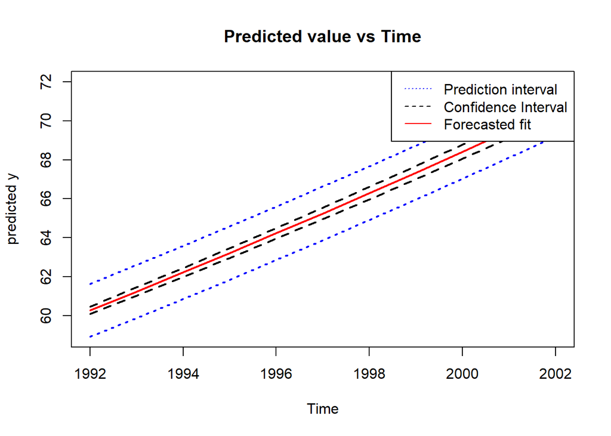

```r
#Plotting the graph with the 95% confidence and prediction intervals
tn=data.frame(t=seq(1992,2002))
pred=predict(lm(female_ts~t+I(t^2)), tn, se.fit = TRUE)
#plot(c(male_ts,pred$fit),type='l',xlim=c(1940,2000))
pred.plim = predict(lm(female_ts~t+I(t^2)),tn, level =0.95, interval="prediction")
pred.clim = predict(lm(female_ts~t+I(t^2)), tn,level=0.95, interval="confidence")
matplot(tn$t,cbind(pred.clim, pred.plim[,-1]),
        lty=c(1,2,2,3,3), type="l", lwd=2, ylab="predicted y",xlab="Time", col =         c("red", "black", "black", "blue","blue"))
title(main = "Predicted value vs Time")
legend("topright", legend = c("Prediction interval", "Confidence Interval", "Forecasted fit"), lty = c(3,2,1), col = c("blue", "black", "red"))
```

The plot shows that there is a upward trend of the female participation rate. The small interval provides strong evidence of the upward trend, since it indicates that the values are not going to vary by much.

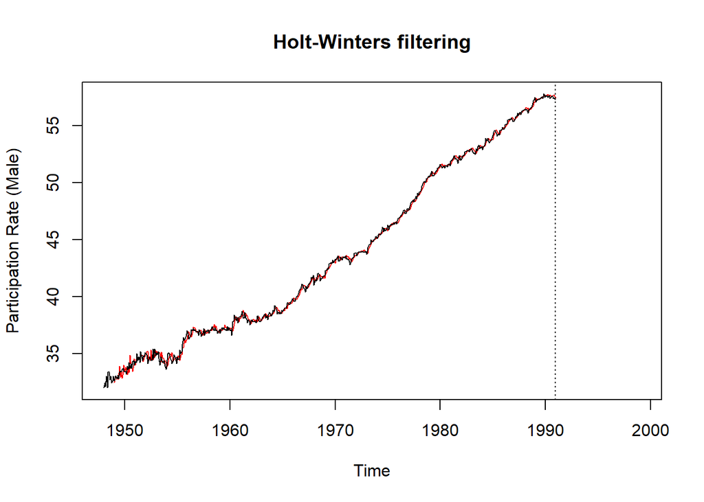

```r
fit_hw = HoltWinters(female_ts)
hwpred = predict(fit_hw, ahead = 120, prediction.interval = T, level = 0.5)
plot(fit_hw, hwpred, ylab="Participation Rate (Male)", xlab="Time", lwd=1, col='black',xlim=c(1948,1999))
```

The holt-winters model is much better than the my model fitting the data.

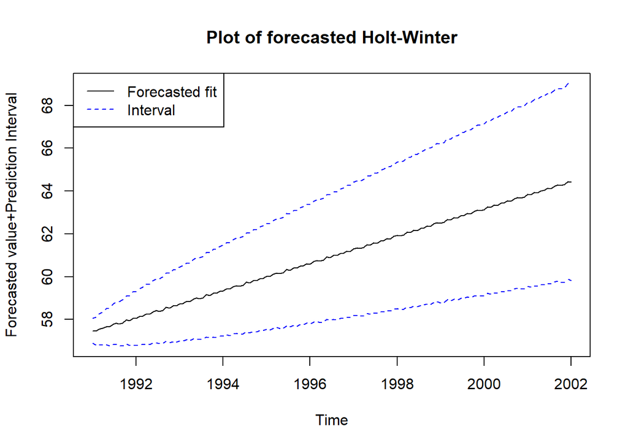

```r
#Create a prediction time series and then plot it
pred_hw=predict(fit_hw, 144, prediction.interval=T, level =0.95)
t2 = seq(from = 1991, to = 2002, length = length(pred_hw[,1]))
matplot(t2, cbind(pred_hw), col = c("black", "blue", "blue"), type = "l", lty = c(1,2,2), xlab = "Time", ylab = "Forecasted value+Prediction Interval")
title(main = "Plot of forecasted Holt-Winter")
legend("topleft", legend=c("Forecasted fit", "Interval"), lty = c(1,2), col = c("black", "blue"))
```

Just like the previous forecast, the Holt-Winters also predict an upward trend.

## Problem 2

Clearing previous problem’s data and obtaining the data for this problem

```r
rm(list=ls(all=T))
data = read.csv("3.2.csv")
attach(data)
```

Calculate the monthly inflation and the ex post interest rate

```r
month_inf = diff(log(cpi))
ex_post_IR = nomrate - month_inf
```

Obtain the data and get the growth rates of the personal real expenditure and income

```r
data1 = read.csv("3.1.csv", header = T)
attach(data1)
rpce_pctchg = diff(log(rpce))
rdpi_pctchg = diff(log(rdpi))

y = lm(rpce_pctchg~rdpi_pctchg+ex_post_IR[-length(ex_post_IR)])
summary(y)
```

```
##
## Call:
## lm(formula = rpce_pctchg ~ rdpi_pctchg + ex_post_IR[-length(ex_post_IR)])
##
## Residuals:
##        Min         1Q     Median         3Q        Max
## -0.0303536 -0.0030060  0.0001328  0.0031119  0.0242241
##
## Coefficients:
##                                   Estimate Std. Error t value Pr(>|t|)
## (Intercept)                      2.732e-03  4.252e-04   6.426 2.57e-10 ***
## rdpi_pctchg                      1.745e-01  2.919e-02   5.978 3.76e-09 ***
## ex_post_IR[-length(ex_post_IR)] -9.430e-05  7.127e-05  -1.323    0.186
## ---
## Signif. codes:  0 '***' 0.001 '**' 0.01 '*' 0.05 '.' 0.1 ' ' 1
##
## Residual standard error: 0.005314 on 636 degrees of freedom
## Multiple R-squared:  0.05572,    Adjusted R-squared:  0.05275
## F-statistic: 18.76 on 2 and 636 DF,  p-value: 1.21e-08
```

The ex post interest rate is statistically insignicant since it has a high p-value corresponding to the t-value. This means that interest rates do not affect consumption significantly.

```r
rm(list=ls(all=T))
data = read.csv("4.4.csv")
names(data) = c("time", "house_price", "interest_rate")
attach(data)
```

Creating the lags

```r
hp_lag1 = append(NA, house_price[-length(house_price)])
hp_lag2 = append(c(NA, NA), house_price[-c(length(house_price)-1, length(house_price))])
hp_lag3 = append(c(NA,NA,NA), house_price[-c(length(house_price)-2, length(house_price)-1, length(house_price))])
hp_lag4 = append(c(NA,NA,NA,NA), house_price[-c(length(house_price)-3, length(house_price)-2, length(house_price)-1, length(house_price))])

house_price_ts = ts(house_price, start=1980+(1/4), freq=4)
hp_lag1k = append(NA, house_price_ts[-length(house_price_ts)])
hp_lag2k = append(c(NA, NA), house_price_ts[-c(length(house_price_ts)-1, length(house_price_ts))])
```

Running the regression

```r
y1 = lm(house_price~hp_lag1)
summary(y1)
```

```
##
## Call:
## lm(formula = house_price ~ hp_lag1)
##
## Residuals:
##     Min      1Q  Median      3Q     Max
## -7.9614 -0.5420 -0.0603  0.8552  5.7695
##
## Coefficients:
##             Estimate Std. Error t value Pr(>|t|)
## (Intercept) 1.151359   0.482284   2.387   0.0185 *
## hp_lag1     0.994223   0.004987 199.345   <2e-16 ***
## ---
## Signif. codes:  0 '***' 0.001 '**' 0.01 '*' 0.05 '.' 0.1 ' ' 1
##
## Residual standard error: 1.971 on 123 degrees of freedom
##   (1 observation deleted due to missingness)
## Multiple R-squared:  0.9969, Adjusted R-squared:  0.9969
## F-statistic: 3.974e+04 on 1 and 123 DF,  p-value: < 2.2e-16
```

```r
y2 = lm(house_price~hp_lag1+hp_lag2)
summary(y2)
```

```
##
## Call:
## lm(formula = house_price ~ hp_lag1 + hp_lag2)
##
## Residuals:
##     Min      1Q  Median      3Q     Max
## -6.3062 -0.5199 -0.0915  0.4563  5.2367
##
## Coefficients:
##             Estimate Std. Error t value Pr(>|t|)
## (Intercept)  0.60462    0.38224   1.582    0.116
## hp_lag1      1.63444    0.06994  23.370  < 2e-16 ***
## hp_lag2     -0.63870    0.06966  -9.169 1.54e-15 ***
## ---
## Signif. codes:  0 '***' 0.001 '**' 0.01 '*' 0.05 '.' 0.1 ' ' 1
##
## Residual standard error: 1.526 on 121 degrees of freedom
##   (2 observations deleted due to missingness)
## Multiple R-squared:  0.9982, Adjusted R-squared:  0.9981
## F-statistic: 3.268e+04 on 2 and 121 DF,  p-value: < 2.2e-16
```

```r
y3 = lm(house_price~hp_lag1+hp_lag2+hp_lag3)
summary(y3)
```

```
##
## Call:
## lm(formula = house_price ~ hp_lag1 + hp_lag2 + hp_lag3)
##
## Residuals:
##     Min      1Q  Median      3Q     Max
## -6.2978 -0.5236 -0.0765  0.5041  4.4598
##
## Coefficients:
##             Estimate Std. Error t value Pr(>|t|)
## (Intercept)  0.64578    0.38173   1.692   0.0933 .
## hp_lag1      1.76283    0.09025  19.532  < 2e-16 ***
## hp_lag2     -0.96606    0.16314  -5.922 3.16e-08 ***
## hp_lag3      0.19904    0.08994   2.213   0.0288 *
## ---
## Signif. codes:  0 '***' 0.001 '**' 0.01 '*' 0.05 '.' 0.1 ' ' 1
##
## Residual standard error: 1.508 on 119 degrees of freedom
##   (3 observations deleted due to missingness)
## Multiple R-squared:  0.9982, Adjusted R-squared:  0.9982
## F-statistic: 2.2e+04 on 3 and 119 DF,  p-value: < 2.2e-16
```

```r
y4 = lm(house_price~hp_lag1+hp_lag2+hp_lag3+hp_lag4)
summary(y4)
```

```
##
## Call:
## lm(formula = house_price ~ hp_lag1 + hp_lag2 + hp_lag3 + hp_lag4)
##
## Residuals:
##     Min      1Q  Median      3Q     Max
## -4.2702 -0.3729 -0.0112  0.3764  2.9768
##
## Coefficients:
##             Estimate Std. Error t value Pr(>|t|)
## (Intercept)  0.47964    0.25512    1.88   0.0626 .
## hp_lag1      1.94090    0.06130   31.66   <2e-16 ***
## hp_lag2     -1.77240    0.12563  -14.11   <2e-16 ***
## hp_lag3      1.61520    0.12805   12.61   <2e-16 ***
## hp_lag4     -0.78871    0.06317  -12.48   <2e-16 ***
## ---
## Signif. codes:  0 '***' 0.001 '**' 0.01 '*' 0.05 '.' 0.1 ' ' 1
##
## Residual standard error: 0.9956 on 117 degrees of freedom
##   (4 observations deleted due to missingness)
## Multiple R-squared:  0.9992, Adjusted R-squared:  0.9992
## F-statistic: 3.731e+04 on 4 and 117 DF,  p-value: < 2.2e-16
```

```r
y5 = lm(house_price_ts~hp_lag1k+hp_lag2k)
summary(y5)
```

```
##
## Call:
## lm(formula = house_price_ts ~ hp_lag1k + hp_lag2k)
##
## Residuals:
##     Min      1Q  Median      3Q     Max
## -6.3062 -0.5199 -0.0915  0.4563  5.2367
##
## Coefficients:
##             Estimate Std. Error t value Pr(>|t|)
## (Intercept)  0.60462    0.38224   1.582    0.116
## hp_lag1k     1.63444    0.06994  23.370  < 2e-16 ***
## hp_lag2k    -0.63870    0.06966  -9.169 1.54e-15 ***
## ---
## Signif. codes:  0 '***' 0.001 '**' 0.01 '*' 0.05 '.' 0.1 ' ' 1
##
## Residual standard error: 1.526 on 121 degrees of freedom
##   (2 observations deleted due to missingness)
## Multiple R-squared:  0.9982, Adjusted R-squared:  0.9981
## F-statistic: 3.268e+04 on 2 and 121 DF,  p-value: < 2.2e-16
```

We can that the coefficients for the odd number of lags are positive and the even number of lags are negative, which means that there is a cycle that goes positive and negative between lags. We also see that the R^2 is large, which shows that the autoregression fits the data well.

## Problem 4

Clearing previous problem’s data and obtaining the data for this problem

```r
rm(list=ls(all=T))
data = read.csv("4.41.csv")
names(data) = c("data", "actual_rgdp_growth", "actual_greenbook_growth")
attach(data)
```

Forecast error

```r
forecast_err = actual_rgdp_growth-actual_greenbook_growth
```

Plot the time series of realized values, forecasts, and forecast errors.

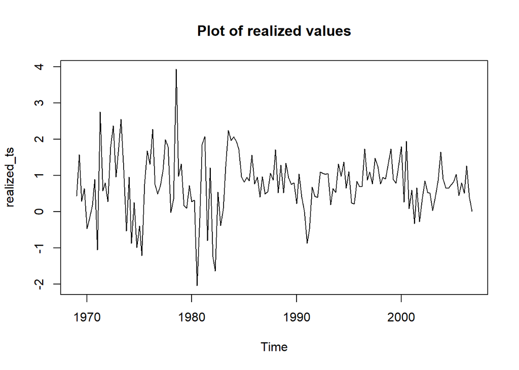

```r
realized_ts = ts(actual_rgdp_growth, start = 1969, freq = 4)
forecast_ts = ts(actual_greenbook_growth, start = 1969, freq = 4)
forecast_error_ts = ts(forecast_err, start = 1969, freq = 4)

plot(realized_ts, main = "Plot of realized values")
```

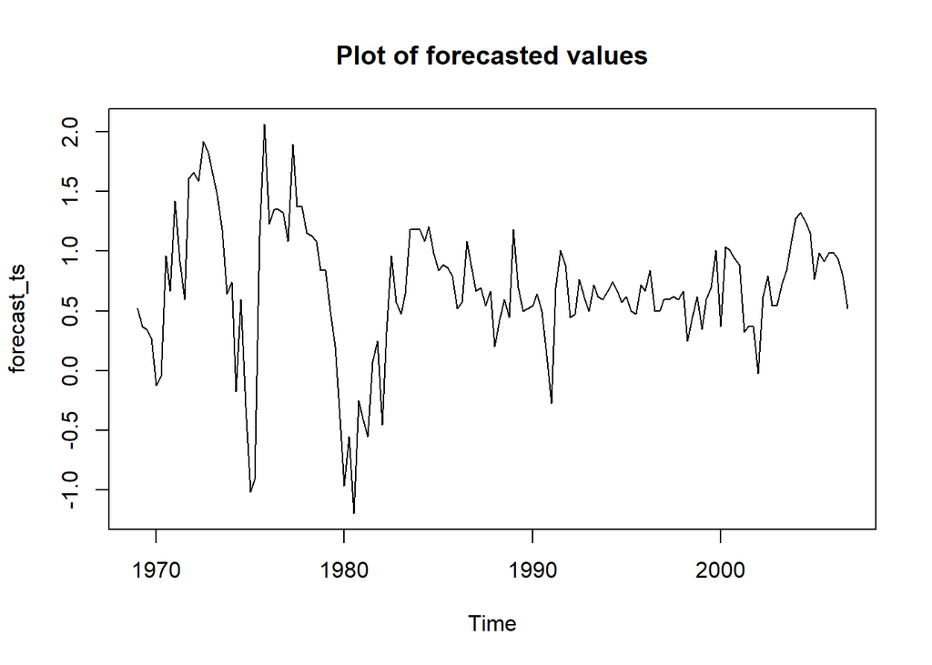

```r
plot(forecast_ts, main = "Plot of forecasted values")
```

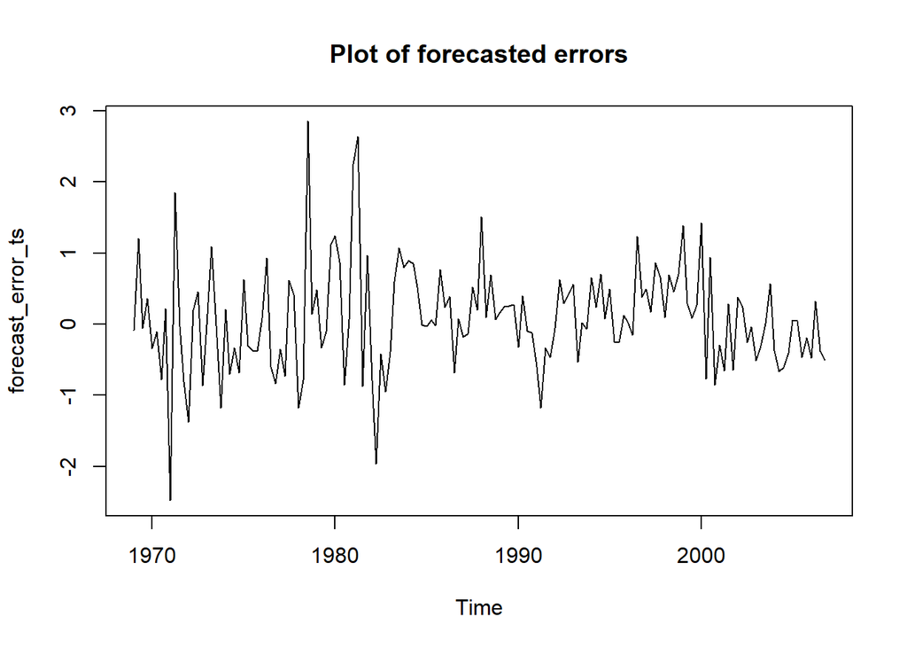

```r
plot(forecast_error_ts, main = "Plot of forecasted errors")
```

All 3 graphs might be first-order weakly stationary, with the second one least likely to be, since there is a sharp decline near the year 1980. It is very unlikely that the graphs are covariance stationary since the values vary more during the first half of the period.

Compute the descriptive statistics and the boxplots

```r
summary(realized_ts)
```

```
##    Min. 1st Qu.  Median    Mean 3rd Qu.    Max.
## -2.0497  0.3475  0.7679  0.7539  1.1741  3.9343
```

```r
summary(forecast_ts)
```

```
##    Min. 1st Qu.  Median    Mean 3rd Qu.    Max.
## -1.1963  0.4901  0.6683  0.6765  0.9914  2.0604
```

```r
summary(forecast_error_ts)
```

```
##     Min.  1st Qu.   Median     Mean  3rd Qu.     Max.
## -2.48030 -0.37236  0.05326  0.07746  0.48582  2.85204
```

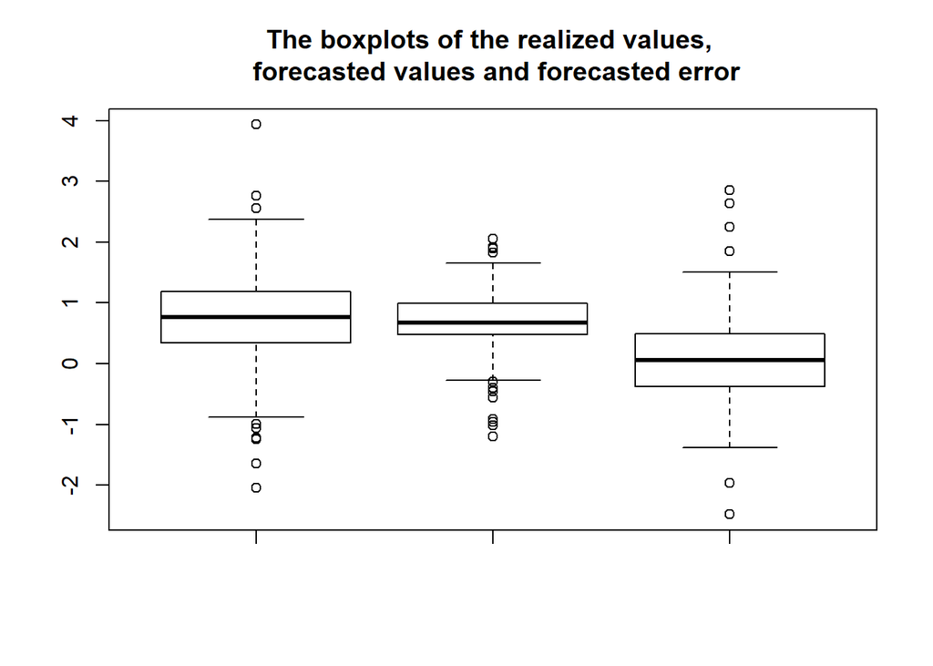

```r
boxplot(realized_ts, forecast_ts, forecast_error_ts, main = "The boxplots of the realized values, \n forecasted values and forecasted error")
```

Compute the ACF and PACF of the realized values, forecasts, and forecast errors and also the Ljung-box test for the forecasted values: The first ACF and PACF are of the realized values, followed by forecasted values and forecasted errors

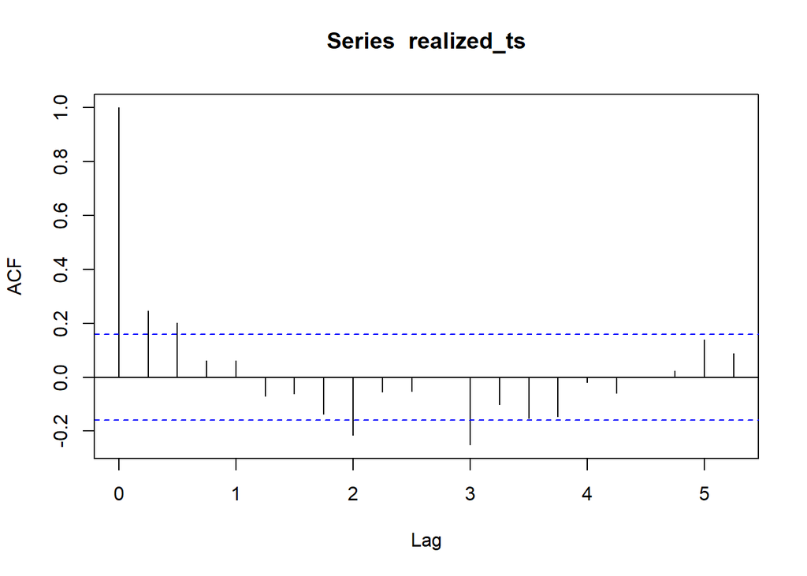

```r
acf(realized_ts)
```

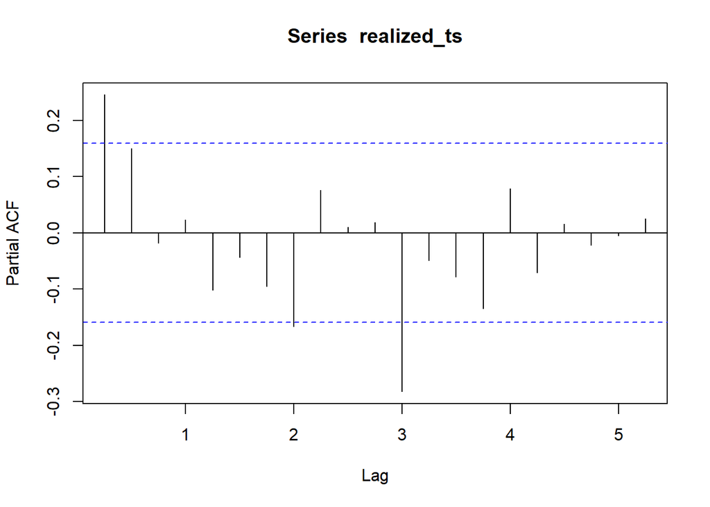

```r
pacf(realized_ts)
```

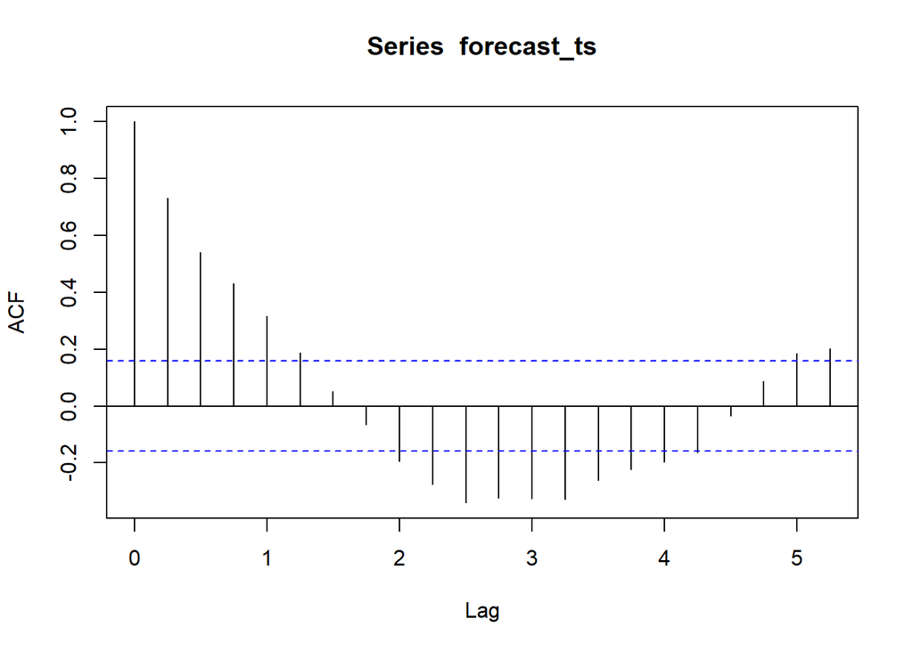

```r
acf(forecast_ts)
```

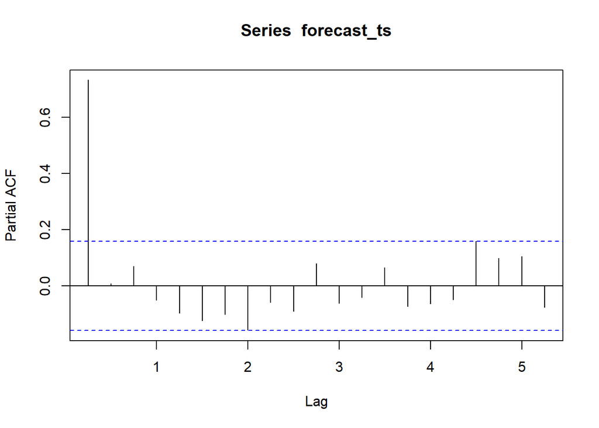

```r
pacf(forecast_ts)
```

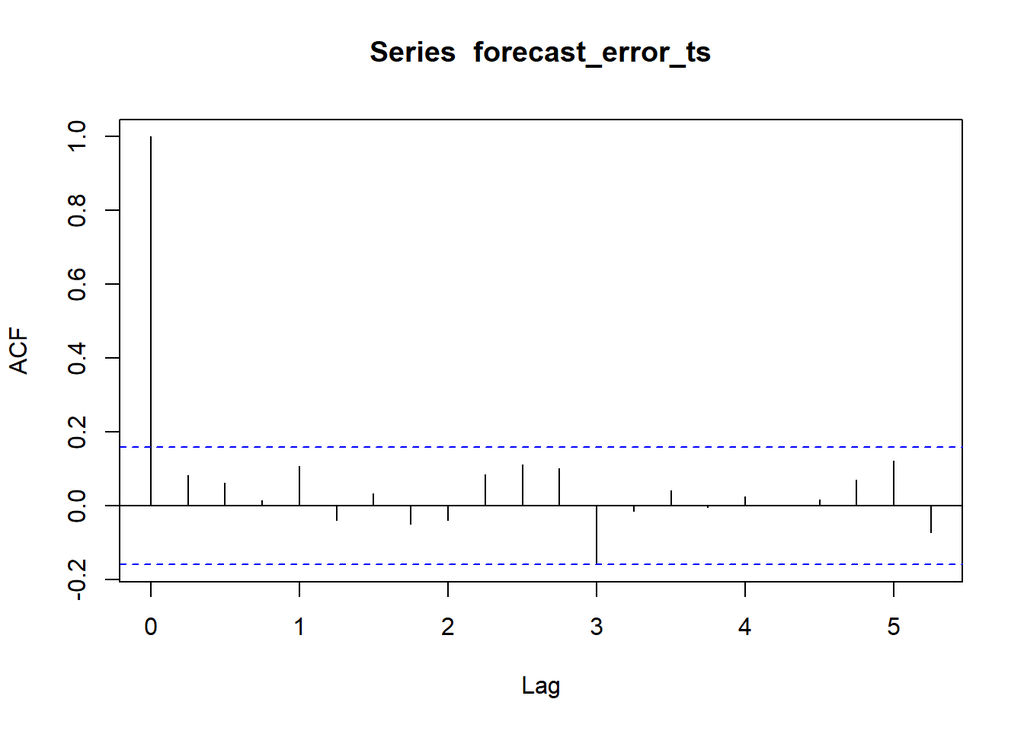

```r
acf(forecast_error_ts)
```

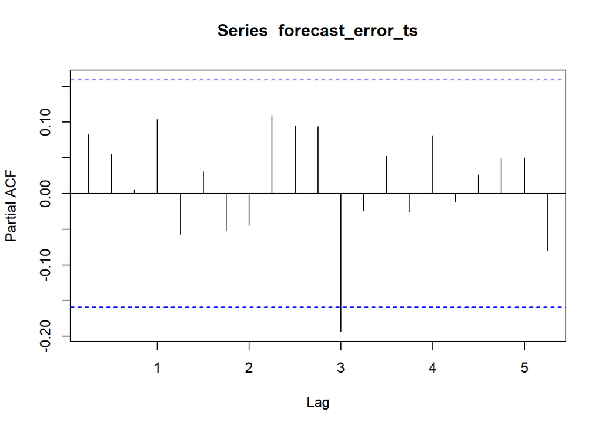

```r
pacf(forecast_error_ts)
```

```r
for (i in 1:20){
  print(Box.test(realized_ts, lag = i, type = "Ljung-Box"))
}
```

```
##
##  Box-Ljung test
##
## data:  realized_ts
## X-squared = 9.3202, df = 1, p-value = 0.002266
##
##
##  Box-Ljung test
##
## data:  realized_ts
## X-squared = 15.637, df = 2, p-value = 0.0004022
##
##
##  Box-Ljung test
##
## data:  realized_ts
## X-squared = 16.242, df = 3, p-value = 0.001011
##
##
##  Box-Ljung test
##
## data:  realized_ts
## X-squared = 16.834, df = 4, p-value = 0.002082
##
##
##  Box-Ljung test
##
## data:  realized_ts
## X-squared = 17.608, df = 5, p-value = 0.00348
##
##
##  Box-Ljung test
##
## data:  realized_ts
## X-squared = 18.217, df = 6, p-value = 0.005713
##
##
##  Box-Ljung test
##
## data:  realized_ts
```

[output cut: 64 more lines]

```
##
## data:  realized_ts
## X-squared = 50.187, df = 18, p-value = 7.072e-05
##
##
##  Box-Ljung test
##
## data:  realized_ts
## X-squared = 50.284, df = 19, p-value = 0.000119
##
##
##  Box-Ljung test
##
## data:  realized_ts
## X-squared = 53.725, df = 20, p-value = 6.354e-05
```

```r
for (i in 1:20){
  print(Box.test(forecast_ts, lag = i, type = "Ljung-Box"))
}
```

```
##
##  Box-Ljung test
##
## data:  forecast_ts
## X-squared = 83.134, df = 1, p-value < 2.2e-16
##
##
##  Box-Ljung test
##
## data:  forecast_ts
## X-squared = 128.59, df = 2, p-value < 2.2e-16
##
##
##  Box-Ljung test
##
## data:  forecast_ts
## X-squared = 157.67, df = 3, p-value < 2.2e-16
##
##
##  Box-Ljung test
##
## data:  forecast_ts
## X-squared = 173.53, df = 4, p-value < 2.2e-16
##
##
##  Box-Ljung test
##
## data:  forecast_ts
## X-squared = 179.13, df = 5, p-value < 2.2e-16
##
##
##  Box-Ljung test
##
## data:  forecast_ts
## X-squared = 179.57, df = 6, p-value < 2.2e-16
##
##
##  Box-Ljung test
##
## data:  forecast_ts
```

[output cut: 64 more lines]

```
##
## data:  forecast_ts
## X-squared = 302.79, df = 18, p-value < 2.2e-16
##
##
##  Box-Ljung test
##
## data:  forecast_ts
## X-squared = 304.11, df = 19, p-value < 2.2e-16
##
##
##  Box-Ljung test
##
## data:  forecast_ts
## X-squared = 310.12, df = 20, p-value < 2.2e-16
```

```r
for (i in 1:20){
  print(Box.test(forecast_error_ts, lag = i, type = "Ljung-Box"))
}
```

```
##
##  Box-Ljung test
##
## data:  forecast_error_ts
## X-squared = 1.0542, df = 1, p-value = 0.3045
##
##
##  Box-Ljung test
##
## data:  forecast_error_ts
## X-squared = 1.6462, df = 2, p-value = 0.4391
##
##
##  Box-Ljung test
##
## data:  forecast_error_ts
## X-squared = 1.6825, df = 3, p-value = 0.6408
##
##
##  Box-Ljung test
##
## data:  forecast_error_ts
## X-squared = 3.5204, df = 4, p-value = 0.4748
##
##
##  Box-Ljung test
##
## data:  forecast_error_ts
## X-squared = 3.7525, df = 5, p-value = 0.5856
##
##
##  Box-Ljung test
##
## data:  forecast_error_ts
## X-squared = 3.936, df = 6, p-value = 0.6853
##
##
##  Box-Ljung test
##
## data:  forecast_error_ts
```

[output cut: 64 more lines]

```
##
## data:  forecast_error_ts
## X-squared = 14.204, df = 18, p-value = 0.7157
##
##
##  Box-Ljung test
##
## data:  forecast_error_ts
## X-squared = 15.102, df = 19, p-value = 0.7161
##
##
##  Box-Ljung test
##
## data:  forecast_error_ts
## X-squared = 17.698, df = 20, p-value = 0.6073
```

According to the ACF and PACF of the realized values, there is a significant correlation in the 2nd and the 3rd lags, while those of the forecasted errors, there is significant correlation in the 3rd lag. This means that there is definitely a significant correlation for the 3rd lag. From the Ljung-Box test, there seems to be significant time dependence for the realized values and the forecasted values, but not the forecasted errors, which means that the forecasted errors are random.

## Problem 5

Clearing previous problem’s data and obtaining the data for this problem

```r
rm(list=ls(all=T))
data = read.csv("5.4.csv")
data$X = NULL
names(data)=c("data_AMEX", "AMEX", "data_SP500", "SP500")
attach(data)
```

Taking the first difference for both the AMEX and the SP500 data to create the returns and then create a time series objects out of them

```r
AMEX_diff = diff(AMEX)
SP500_diff = diff(SP500)

#y1 = time series for AMEX and y2 = time series for SP500
y1 = ts(AMEX_diff, start=1995+(249/252), freq = 252)
y2 = ts(SP500_diff, start = 1990+(13/252), freq = 252)

#need to get rid of the NA's in the y1 and y2 data
y1 = y1[complete.cases(y1)]
y2 = y2[complete.cases(y2)]
```

Calculating the ACF and PACF for both of the returns. First ACF and PACF belongs to the returns of AMEX, followed by the SP500.

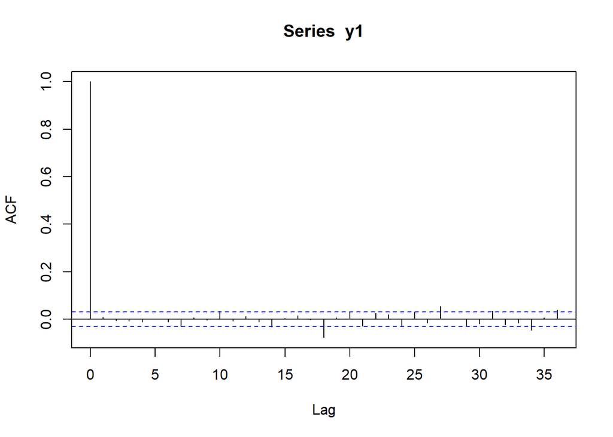

```r
acf(y1)
```

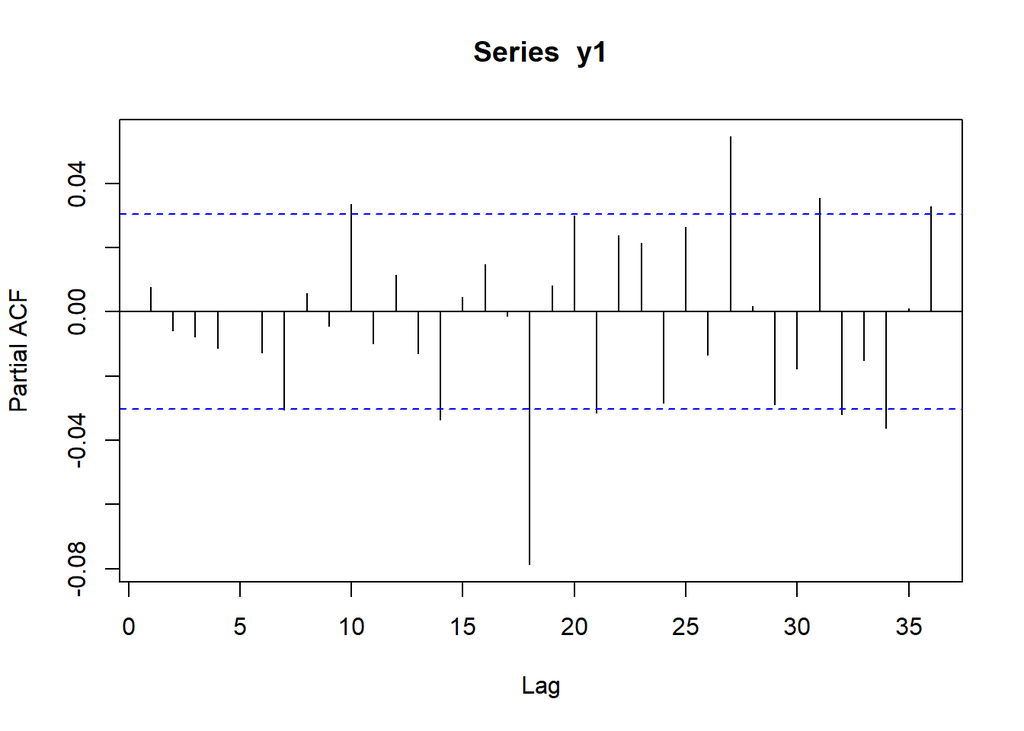

```r
pacf(y1)
```

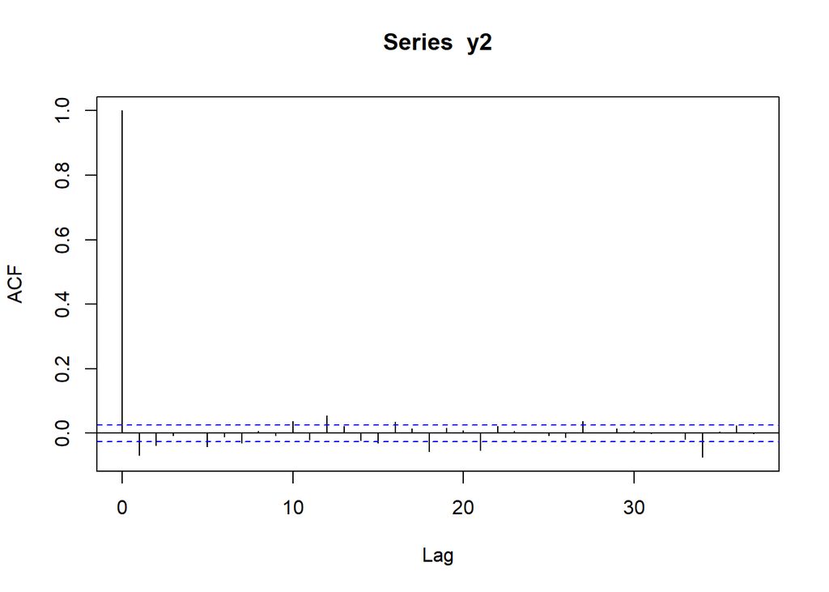

```r
acf(y2)
```

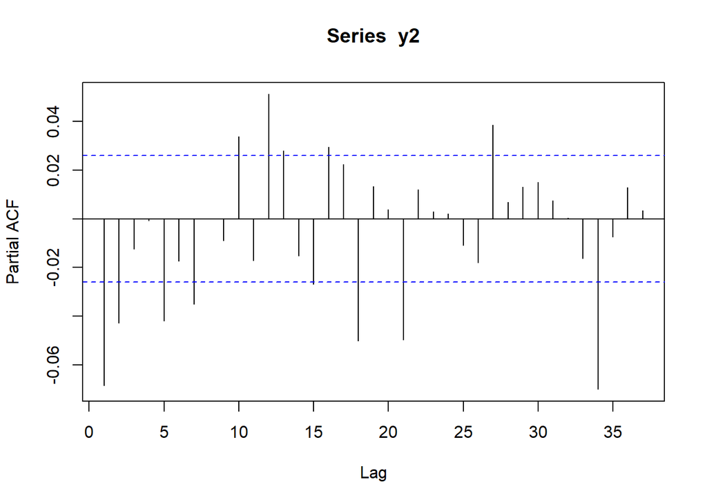

```r
pacf(y2)
```

```r
for (i in 1:20){
  print(Box.test(y1, lag = i, type = "Ljung-Box"))
}
```

```
##
##  Box-Ljung test
##
## data:  y1
## X-squared = 0.23909, df = 1, p-value = 0.6249
##
##
##  Box-Ljung test
##
## data:  y1
## X-squared = 0.38156, df = 2, p-value = 0.8263
##
##
##  Box-Ljung test
##
## data:  y1
## X-squared = 0.64424, df = 3, p-value = 0.8862
##
##
##  Box-Ljung test
##
## data:  y1
## X-squared = 1.177, df = 4, p-value = 0.8819
##
##
##  Box-Ljung test
##
## data:  y1
## X-squared = 1.177, df = 5, p-value = 0.9471
##
##
##  Box-Ljung test
##
## data:  y1
## X-squared = 1.8304, df = 6, p-value = 0.9346
##
##
##  Box-Ljung test
##
## data:  y1
```

[output cut: 64 more lines]

```
##
## data:  y1
## X-squared = 42.902, df = 18, p-value = 0.0008261
##
##
##  Box-Ljung test
##
## data:  y1
## X-squared = 43.049, df = 19, p-value = 0.001276
##
##
##  Box-Ljung test
##
## data:  y1
## X-squared = 47.715, df = 20, p-value = 0.0004663
```

```r
for (i in 1:20){
  print(Box.test(y2, lag = i, type = "Ljung-Box"))
}
```

```
##
##  Box-Ljung test
##
## data:  y2
## X-squared = 26.623, df = 1, p-value = 2.473e-07
##
##
##  Box-Ljung test
##
## data:  y2
## X-squared = 34.813, df = 2, p-value = 2.758e-08
##
##
##  Box-Ljung test
##
## data:  y2
## X-squared = 35.053, df = 3, p-value = 1.187e-07
##
##
##  Box-Ljung test
##
## data:  y2
## X-squared = 35.085, df = 4, p-value = 4.462e-07
##
##
##  Box-Ljung test
##
## data:  y2
## X-squared = 44.673, df = 5, p-value = 1.691e-08
##
##
##  Box-Ljung test
##
## data:  y2
## X-squared = 45.385, df = 6, p-value = 3.923e-08
##
##
##  Box-Ljung test
##
## data:  y2
```

[output cut: 64 more lines]

```
##
## data:  y2
## X-squared = 113.48, df = 18, p-value = 6.661e-16
##
##
##  Box-Ljung test
##
## data:  y2
## X-squared = 114.89, df = 19, p-value = 9.992e-16
##
##
##  Box-Ljung test
##
## data:  y2
## X-squared = 115.34, df = 20, p-value = 2.109e-15
```